# What Drives MLB Hitting Production?

Bat tracking, swing profiles and development levers – public Statcast data

**NoteKey findings**

1. **Bat speed is the strongest correlate of production.** At equal swing length and contact, +1 mph of bat speed is associated with about +10 points of xwOBA across 232 qualified hitters.
2. **Efficiency matters.** At equal bat speed, a longer swing tends to go with lower production (significant in the swing-only model), suggesting that efficient speed matters more than a longer path.
3. **There is no single ideal swing.** Four distinct hitter profiles reach similar production through different routes, suggesting that development should be individualized.
4. **Bat speed and production move together over time.** Among 163 hitters qualified in both seasons, a change in bat speed from 2025 to 2026 went with a change in xwOBA in the same direction (r = 0.40, about 11 points per mph). An association, not proof of cause: it shows where development questions are worth testing.
5. **Public data explains about half of the picture.** Swing metrics explain 41% of the differences in xwOBA between hitters, 45% with swing decisions added (adjusted R²), chasing fewer pitches out of the zone being the decision that matters most. The rest is where biomechanics data adds the most value.

**Explore:** Blue Jays team overview · Example player report: Ernie Clement

## What drives hitting production

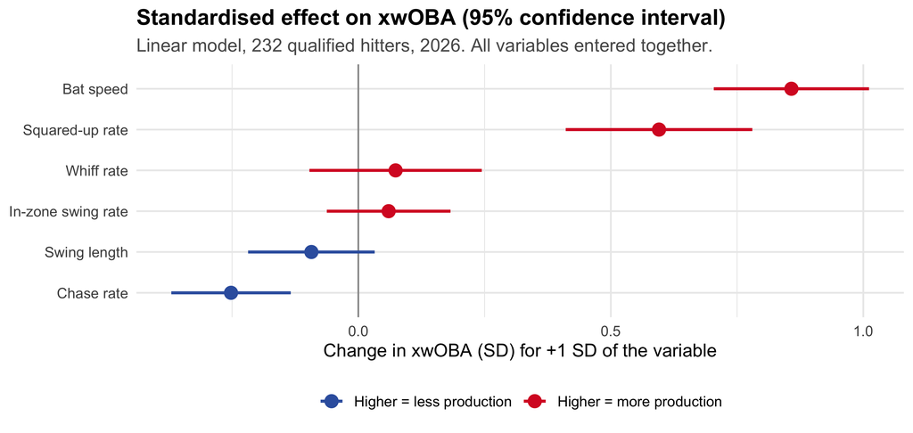

Bat speed, squared-up rate and chase rate are the clearest signals. The small positive sign of whiff rate should not be read on its own: whiffs overlap with contact quality and swing length, which already carry that information. Each variable’s effect is measured **with the others held constant**, on a common scale (standard deviations), so the bars can be compared. Effects whose interval crosses zero are not distinguishable from no effect. These are associations across hitters, not proof that changing one variable will move production by that amount: they point to the hypotheses worth testing in player development.

## The speed–efficiency trade-off

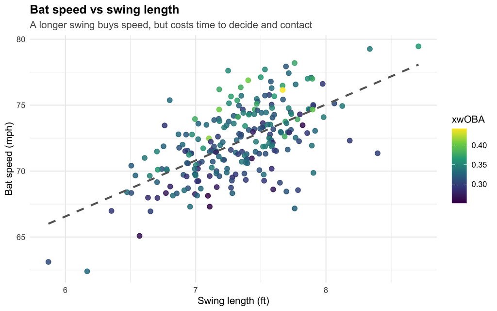

Hitters who generate speed **without** a long swing (top-left of the cloud) tend to produce the most. The development question is therefore not only *how fast* but *how efficiently*.

## Four hitter profiles

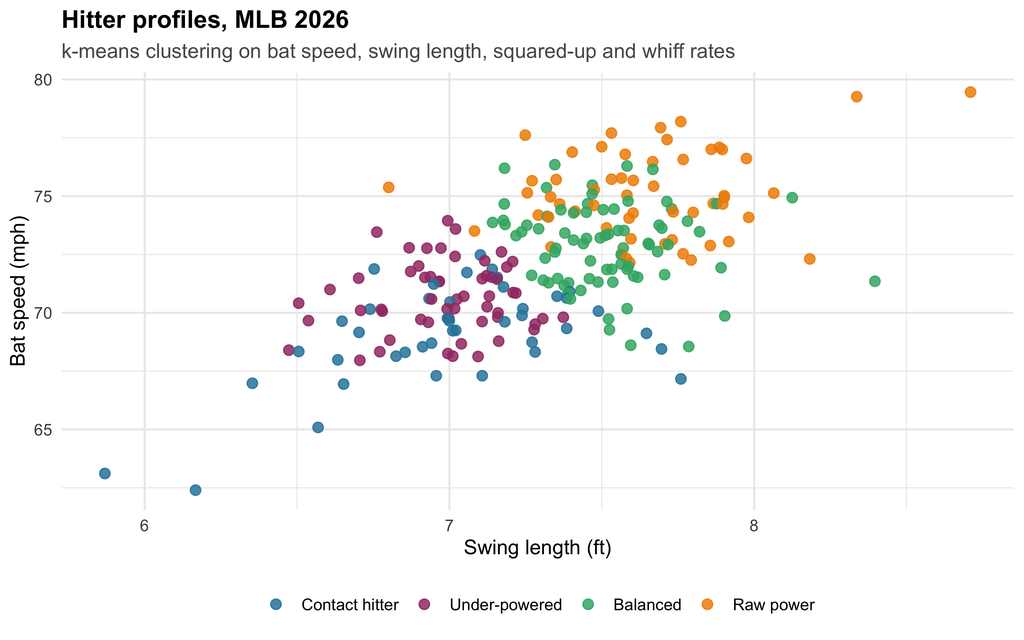

| Profile | Hitters | Bat speed (mph) | Swing length (ft) | Squared-up / swing | Whiff / swing | xwOBA | What it looks like | Main lever |
| --- | --- | --- | --- | --- | --- | --- | --- | --- |
| Contact hitter | 42 | 69.1 | 7.00 | 32.3% | 14.0% | 0.320 | Short, controlled swing; elite contact, little impact | Add bat speed, protect contact |
| Under-powered | 56 | 70.7 | 6.99 | 25.3% | 23.1% | 0.313 | Below-average speed and average contact | Bat speed (physical screen first) |
| Balanced | 78 | 72.9 | 7.51 | 25.1% | 22.1% | 0.330 | Above-average speed with average contact | Maintain; refine decisions |
| Raw power | 56 | 75.1 | 7.65 | 20.3% | 29.8% | 0.328 | Fastest, longest swings; most whiffs | Contact quality & swing efficiency |

Production differs far less **between** profiles than the swings themselves do: contact hitters and raw-power hitters reach comparable xwOBA by opposite routes. Each profile has its own lever, which is why every player report starts from the profile before proposing an intervention.

## Does gaining bat speed pay off?

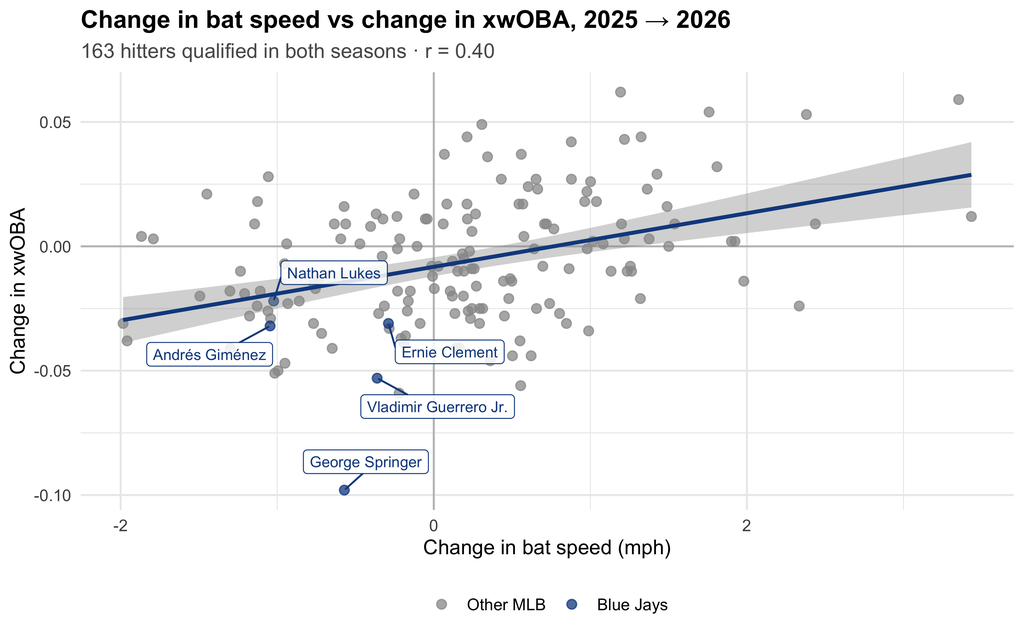

This is the closest public proxy for **intervention effectiveness**: when a hitter’s bat speed moves, does his production follow? It mixes training effects with ageing, injuries and noise, so it frames the question rather than answers it. With internal data, the same view could isolate players who went through a specific programme.

## Method and limits

- **Data:** Baseball Savant public Statcast leaderboards (bat tracking, expected statistics, exit velocity and barrels, plate discipline), 2025–2026.
- **Reference group:** 232 qualified hitters (570+ competitive swings). Models, profiles and percentiles are built on this group; hitters with fewer swings are placed against it and flagged as small samples.
- **Outcome:** xwOBA, which values contact quality and plate outcomes while removing much of the luck of defence and ballparks. Actual wOBA is shown alongside in player reports.
- **Limits:** cross-sectional associations, not causal effects; one-season windows are noisy; no biomechanical, force-plate or timing data. Those are exactly the layers an internal Performance Science dataset would add.

Analysis and reports built in R (tidyverse, ggplot2) and Quarto, with a reproducible pipeline from raw data to reports. Hugo Leligny.

Hugo Leligny · Sport Scientist & Performance Analyst  
Measure → Analyze → Decide → Train → Monitor → Adapt ↻  
hugoleligny14@gmail.com · [GitHub](https://github.com/hugollel/blue-jays-hitting)